# Проверка гипотез для крупного интернет-магазина

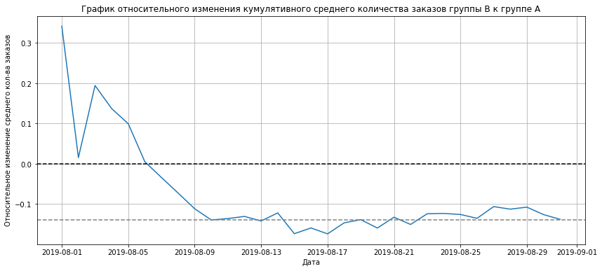

```python
# собираем данные в одном датафрейме
merged_cumulative_orders = cumulative_orders_a.merge(cumulative_orders_b, left_on='date', right_on='date', how='left', suffixes=['A', 'B'])

fig = plt.figure(figsize=(14, 6)) # Размер графика
# cтроим отношение средних чеков
plt.plot(
    merged_cumulative_orders['date'],
    (
        merged_cumulative_orders['visitorsB']/merged_cumulative_orders['ordersB']
    )/(
        merged_cumulative_orders['visitorsA']/merged_cumulative_orders['ordersA']
    )-1
)
plt.title('График относительного изменения кумулятивного среднего количества заказов группы B к группе A')# Заголовок графика
#  Добавляем подписи к осям:
plt.xlabel('Дата')
plt.ylabel('Относительное изменение среднего кол-ва заказов')
plt.grid() # Добавление сетки
# добавляем ось X
plt.axhline(y=-0.14, color='grey', linestyle='--')
plt.axhline(y=0, color='black', linestyle='--');
```

## Построим точечный график количества заказов по пользователям

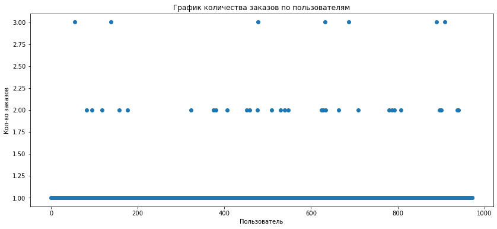

```python
orders_by_users = (
    orders.groupby('visitor_id', as_index=False)
    .agg({'transaction_id': 'nunique'})
)


orders_by_users.columns = ['visitor_id', 'orders']

x_values = pd.Series(range(0,len(orders_by_users)))

fig = plt.figure(figsize=(14, 6)) # Размер графика

plt.title('График количества заказов по пользователям')# Заголовок графика
#  Добавляем подписи к осям:
plt.xlabel('Пользователь')
plt.ylabel('Кол-во заказов')

plt.scatter(x_values, orders_by_users['orders']);
```

Видем что большинство заказов не превышают 2 заказов на пользователя.

## Посчитаем 95-й и 99-й перцентили количества заказов на пользователя и выберем границу для определения аномальных пользователей.

```python
print(np.percentile(orders_by_users['orders'], [95, 99]))
```

```
[1. 2.]
```

- Пользователей совершившие не более *2 заказов* включает **99%** таблицы, *1* - **95%.**
- Примим за аномальных пользователей все кто совершил **больше 1 заказов**

## Построим точечный график стоимостей заказов.

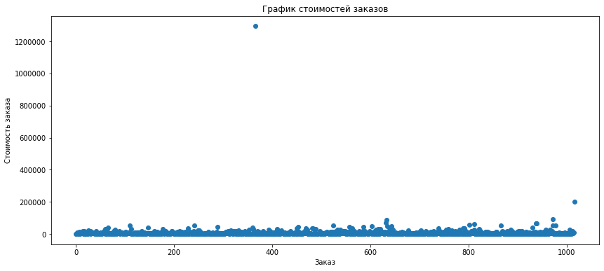

```python
x_values = pd.Series(range(0,len(orders['revenue'])))

fig = plt.figure(figsize=(14, 6)) # Размер графика

plt.title('График стоимостей заказов')# Заголовок графика
#  Добавляем подписи к осям:
plt.xlabel('Заказ')
plt.ylabel('Стоимость заказа')

plt.ticklabel_format(style='plain')
plt.scatter(x_values, orders['revenue']);
```

На графике видем очень аномальный заказ свыше 1.2 млн.

Посмотрим на график без него:

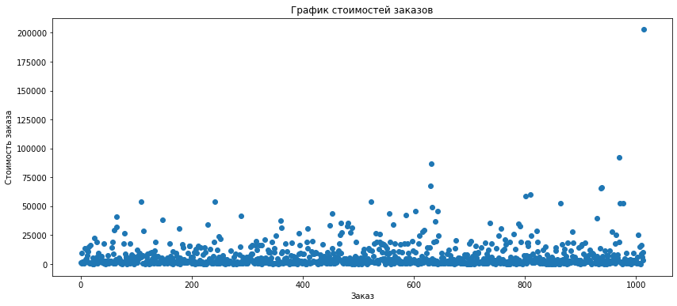

```python
x_values = pd.Series(range(0,len(orders.query('revenue < 1000000')['revenue'])))

fig = plt.figure(figsize=(14, 6)) # Размер графика

plt.title('График стоимостей заказов')# Заголовок графика
#  Добавляем подписи к осям:
plt.xlabel('Заказ')
plt.ylabel('Стоимость заказа')

plt.ticklabel_format(style='plain')
plt.scatter(x_values, orders.query('revenue < 1000000')['revenue']);
```

Видим что большинство заказов не превышают 40000.

## Посчитаем 95-й и 99-й перцентили стоимости заказов и выберем границу для определения аномальных пользователей.

```python
print(np.percentile(orders['revenue'], [95, 99]))
```

```
[26785. 53904.]
```

- 95% - менее **26785** и 99% менее **53904**
- Примим за аномальных заказы все которые **больше 26785**

## Посчитаем статистическую значимость различий в среднем количестве заказов между группами по «сырым» данным

Сформулируем гипотезы:

- **Нулевая**: различий в среднем количестве заказов между группами нет.
- **Альтернативная**: различия в среднем между группами есть.

```python
# Посчитаем количество уникальных заказов для каждого пользователя по группе А
orders_by_users_a = (
    orders[orders['group'] == 'A']
    .groupby('visitor_id', as_index=False)
    .agg({'transaction_id': pd.Series.nunique})
)

orders_by_users_a.columns = ['visitor_id', 'orders']# переменуем столбцы таблицы

# Посчитаем количество уникальных заказов для каждого пользователя по группе B
orders_by_users_b = (
    orders[orders['group'] == 'B']
    .groupby('visitor_id', as_index=False)
    .agg({'transaction_id': pd.Series.nunique})
)

orders_by_users_b.columns = ['visitor_id', 'orders']# переменуем столбцы таблицы

# Посчитаем количество посещений сайта для групп:
visitors_groups = visitors.groupby('group').agg({'visitors':'sum'}).reset_index()

visitors_a = visitors_groups[visitors_groups['group'] == 'A']['visitors'].reset_index(drop=True)
visitors_b = visitors_groups[visitors_groups['group'] == 'B']['visitors'].reset_index(drop=True)

# Соберем таблицу где пользователям из разных групп будет соответствовать количество заказов для групп А и В.
sample_a = pd.concat(
    [orders_by_users_a['orders'],
    pd.Series(0, index=np.arange(visitors_a[0] - len(orders_by_users_a['orders'])), name='orders')],axis=0
)

sample_b = pd.concat(
    [orders_by_users_b['orders'],
    pd.Series(0, index=np.arange(visitors_b[0] - len(orders_by_users_b['orders'])), name='orders')],axis=0
)
# применим тест Манна-Уитни
print('p-value: {0:.5f}'.format(stats.mannwhitneyu(sample_a, sample_b)[1]))
# вычислим относительное различие в среднем
print('Относительное различие в среднем: {0:.3f}'.format(sample_b.mean() / sample_a.mean() - 1))
```

```
p-value: 0.01102
Относительное различие в среднем: 0.160
```

- P-value **меньше 0.05**, потому нулевую гипотезу отвергаем.
- Анализ «сырых данных» сообщает, что в среднем количестве заказов между группами есть статистически значимые различия.
- Относительный прирост среднем количестве заказов группы B к группе A равен **16%**.

## Посчитаем статистическую значимость различий в среднем чеке заказа между группами по «сырым» данным

Сформулируем гипотезы:

- **Нулевая**: различий в среднем чеке между группами нет.
- **Альтернативная**: различия в среднем чеке между группами есть.

```python
# применим тест Манна-Уитни
print('p-value: {0:.3f}'.format(
    stats.mannwhitneyu(
        orders[orders['group']=='A']['revenue'], orders[orders['group']=='B']['revenue']
    )[1]
))
# вычислим относительное различие в среднем
print('Относительное различие в среднем: {0:.3f}'.format(
    orders[orders['group']=='B']['revenue'].mean()/orders[orders['group']=='A']['revenue'].mean()-1
))
```

```
p-value: 0.829
Относительное различие в среднем: 0.287
```

- P-value **больше 0.05** — статистически значимых отличий в среднем чеке между группами нет.
- Относительное различие среднего чека между сегментами **28.7%** в пользу **группы В.**

Большая относительная разница при отсутствии статистической значимости говорит о влиянии выбросов.

## Посчитаем статистическую значимость различий в среднем количестве заказов между группами по «очищенным» данным

Сформулируем гипотезы:

- **Нулевая**: различий без аномальных заказов в среднем количестве заказов между группами нет.
- **Альтернативная**: различия без аномальных заказов в среднем между группами есть.

```python
# получим список пользователей сделавших больше 1 заказов
users_with_many_orders = pd.concat(
    [
        orders_by_users_a[orders_by_users_a['orders'] > np.percentile(orders_by_users['orders'], 95)]['visitor_id'],
        orders_by_users_b[orders_by_users_b['orders'] > np.percentile(orders_by_users['orders'], 95)]['visitor_id'],
    ],
    axis=0,
)
# получим список пользователей сделавших заказы больше 26785
users_with_expensive_orders = orders[orders['revenue'] > np.percentile(orders['revenue'], 95)]['visitor_id']

# объеденим списки удалив дубликаты и отсортируем их
abnormal_users = (
    pd.concat([users_with_many_orders, users_with_expensive_orders], axis=0)
    .drop_duplicates()
    .sort_values()
)

# уберем аномальных пользователей в группе А
sample_a_filtered = pd.concat(
    [
        orders_by_users_a[
            np.logical_not(orders_by_users_a['visitor_id'].isin(abnormal_users))
        ]['orders'],
        pd.Series(
            0,
            index=np.arange(
                visitors_a[0] - len(orders_by_users_a['orders'])
            ),
            name='orders',
        ),
    ],
    axis=0,
)

# уберем аномальных пользователей в группе В
sample_b_filtered = pd.concat(
    [
        orders_by_users_b[
            np.logical_not(orders_by_users_b['visitor_id'].isin(abnormal_users))
        ]['orders'],
        pd.Series(
            0,
            index=np.arange(
                visitors_b[0] - len(orders_by_users_b['orders'])
            ),
            name='orders',
        ),
    ],
    axis=0,
)

# применим тест Манна-Уитни
print('p-value: {0:.5f}'.format(stats.mannwhitneyu(sample_a_filtered, sample_b_filtered)[1]))
# вычислим относительное различие в среднем
print('Относительное различие в среднем: {0:.3f}'.format(sample_b_filtered.mean() / sample_a_filtered.mean() - 1))
```

```
p-value: 0.01593
Относительное различие в среднем: 0.174
```

- Как и в "сырых" данных статистическая значимость достигнута, **группа В лучше группы А**
- Относительное различие **17,4%** в пользу **группы B**

Относительное различие увеличилось на **1,4%** по отношению к не "очищенным" данным(16%).

## Посчитаем статистическую значимость различий в среднем чеке заказа между группами по «очищенным» данным

Сформулируем гипотезы:

- **Нулевая**: различий без аномальных заказов в среднем чеке между группами нет.
- **Альтернативная**: различия без аномальных заказов в среднем чеке между группами есть.

```python
print(
    'p-value: {0:.3f}'.format(
        stats.mannwhitneyu(
            orders[
                np.logical_and(
                    orders['group'] == 'A',
                    np.logical_not(orders['visitor_id'].isin(abnormal_users)),
                )
            ]['revenue'],
            orders[
                np.logical_and(
                    orders['group'] == 'B',
                    np.logical_not(orders['visitor_id'].isin(abnormal_users)),
                )
            ]['revenue'],
        )[1]
    )
)

print(
    'Относительное различие в среднем:{0:.3f}'.format(
        orders[
            np.logical_and(
                orders['group'] == 'B',
                np.logical_not(orders['visitor_id'].isin(abnormal_users)),
            )
        ]['revenue'].mean()
        / orders[
            np.logical_and(
                orders['group'] == 'A',
                np.logical_not(orders['visitor_id'].isin(abnormal_users)),
            )
        ]['revenue'].mean()
        - 1
    )
)
```

```
p-value: 0.727
Относительное различие в среднем:-0.034
```

- При удалении аномальных данных статистически значимых отличий в среднем чеке между группами не появилось.
- А вот относительное различие изменилось в пользу **группы А** на целых **3,4%**

Относительное различие изменилось на **минус 32,1%** по отношению к не "очищенным" данным(28.7% в пользу группы В).

## Посмотрим как изменились графики

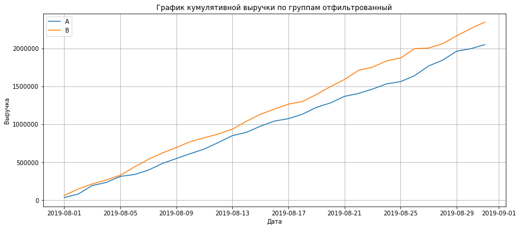

```python
# агриггируем данные по заказам по дате и группе убрав аномальных пользователей
orders_aggregated_filtered = dates_groups.apply(
    lambda x: orders[
        np.logical_and(
            orders['date'] <= x['date'],
            np.logical_and(
                orders['group'] == x['group'],
                np.logical_not(orders['visitor_id'].isin(abnormal_users))
            )
        )
    ].agg(
        {
            'date': 'max',
            'group': 'max',
            'transaction_id': 'nunique',
            'visitor_id': 'nunique',
            'revenue': 'sum',
        }
    ),
    axis=1,
).sort_values(by=['date', 'group'])

# агриггируем данные по посещениям по дате и группе
visitors_aggregated_filtered = dates_groups.apply(
    lambda x: visitors[
        np.logical_and(
            visitors['date'] <= x['date'],
            visitors['group'] == x['group']
        )
    ].agg(
        {
            'date': 'max',
            'group': 'max',
            'visitors': 'sum'
        }
    ),
    axis=1,
).sort_values(by=['date', 'group'])

# объединяем полученные таблицы по заказам и посещениям
cumulative_data_filtered = orders_aggregated_filtered.merge(
    visitors_aggregated_filtered, left_on=['date', 'group'], right_on=['date', 'group']
)

# переименовываем столбцы
cumulative_data_filtered.columns = [
    'date',
    'group',
    'orders',
    'buyers',
    'revenue',
    'visitors',
]

# Отделим группу А из всей таблицы
cumulative_revenue_a_filtered = cumulative_data_filtered[cumulative_data_filtered['group']=='A'][['date','revenue', 'orders','visitors']]

# Отделим группу B из всей таблицы
cumulative_revenue_b_filtered = cumulative_data_filtered[cumulative_data_filtered['group']=='B'][['date','revenue', 'orders','visitors']]


fig = plt.figure(figsize=(14, 6)) # Размер графика

# Строим график выручки группы А
plt.plot(cumulative_revenue_a_filtered['date'], cumulative_revenue_a_filtered['revenue'], label='A')

# Строим график выручки группы B
plt.plot(cumulative_revenue_b_filtered['date'], cumulative_revenue_b_filtered['revenue'], label='B')

plt.title('График кумулятивной выручки по группам отфильтрованный')# Заголовок графика
#  Добавляем подписи к осям:
plt.xlabel('Дата')
plt.ylabel('Выручка')
plt.ticklabel_format(axis='y', style='plain', scilimits=(0,0))#  отображение оси У целым числом
plt.grid()
plt.legend();
```

Группа В стабильно лучше растет постепенно увеличивая разрыв.

Посмотрим на отфильтрованный график кумулятивного среднего чека по группам:

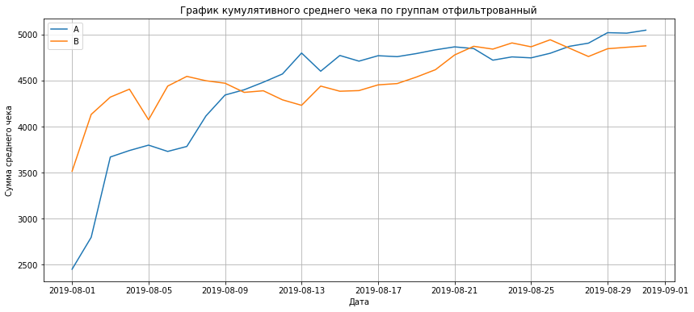

```python
fig = plt.figure(figsize=(14, 6)) # Размер графика
# Строим график выручки группы А
plt.plot(cumulative_revenue_a_filtered['date'], cumulative_revenue_a_filtered['revenue']/cumulative_revenue_a_filtered['orders'], label='A')
# Строим график выручки группы В
plt.plot(cumulative_revenue_b_filtered['date'], cumulative_revenue_b_filtered['revenue']/cumulative_revenue_b_filtered['orders'], label='B')

plt.title('График кумулятивного среднего чека по группам отфильтрованный')# Заголовок графика
plt.grid()
plt.xlabel('Дата')
plt.ylabel('Сумма среднего чека')
plt.legend();
```

В среднем чеке после удалении аномальных заказов обе группы находятся в районе 5000.

Допольнительно взгляним на конверсию(по неочищеным данным так как очистить данные в посещениях мы не можем) в группах:

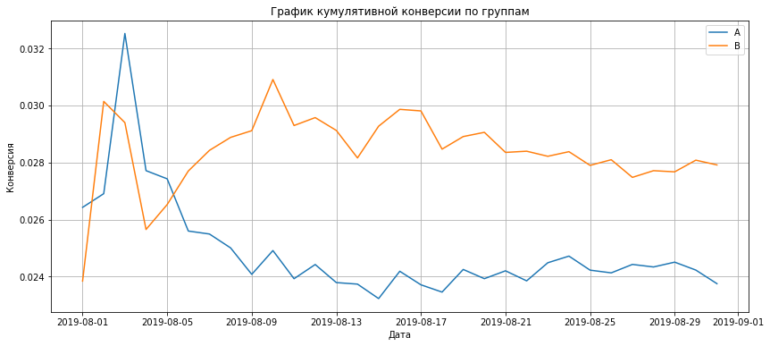

```python
# считаем уникальных пользователей удаляя их повторные покупки:
unique_buyers = (
    orders.drop_duplicates(subset=['visitor_id'], keep='first')
    .groupby(['date','group'])
    .agg({'visitor_id': 'nunique'})
    .reset_index()
)

# объеденяем уникальных покупателей и посетителей
visitors_buyers = unique_buyers.merge(
    visitors, left_on=['date', 'group'], right_on=['date', 'group']
)

visitors_buyers.columns = [
    'date',
    'group',
    'buyers',
    'visitors'
]


# считаем кумулятивные посещения и покупки
cumulative_visitors_buyers = dates_groups.apply(
    lambda x: visitors_buyers[
        np.logical_and(
            visitors_buyers['date'] <= x['date'], visitors_buyers['group'] == x['group']
        )
    ].agg(
        {
            'date': 'max',
            'group': 'max',
            'buyers': 'sum',
            'visitors': 'sum',
        }
    ),
    axis=1,
).sort_values(by=['date', 'group'])

cumulative_visitors_buyers_a = cumulative_visitors_buyers[cumulative_visitors_buyers['group']=='A'].reset_index()
cumulative_visitors_buyers_b = cumulative_visitors_buyers[cumulative_visitors_buyers['group']=='B'].reset_index()

# считаем кумулятивную конверсию
cumulative_visitors_buyers_a['conversion'] = cumulative_visitors_buyers_a['buyers']/cumulative_visitors_buyers_a['visitors']
cumulative_visitors_buyers_b['conversion'] = cumulative_visitors_buyers_b['buyers']/cumulative_visitors_buyers_b['visitors']

fig = plt.figure(figsize=(14, 6)) # Размер графика

# строим графики
plt.plot(cumulative_visitors_buyers_a['date'], cumulative_visitors_buyers_a['conversion'], label='A')
plt.plot(cumulative_visitors_buyers_b['date'], cumulative_visitors_buyers_b['conversion'], label='B')



plt.title('График кумулятивной конверсии по группам')# Заголовок графика
plt.grid()
plt.xlabel('Дата')
plt.ylabel('Конверсия')
plt.legend();
```

График конверсии **группы В стабильно лучше группы А**

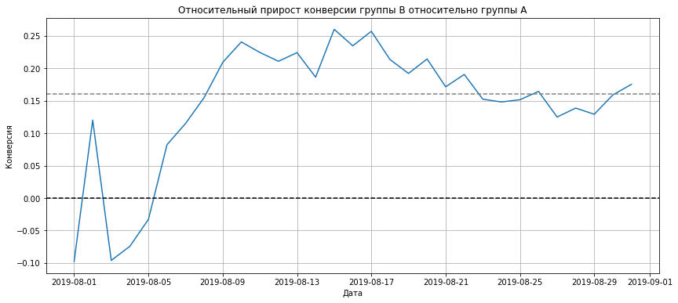

```python
merged_cumulative_conversions = cumulative_visitors_buyers_a[['date','conversion']].merge(cumulative_visitors_buyers_b[['date','conversion']], left_on='date', right_on='date', how='left', suffixes=['A', 'B'])

fig = plt.figure(figsize=(14, 6)) # Размер графика

plt.plot(
    merged_cumulative_conversions['date'],
    merged_cumulative_conversions['conversionB'] / merged_cumulative_conversions['conversionA']-1
    )


plt.title('Относительный прирост конверсии группы B относительно группы A')# Заголовок графика
plt.grid()
plt.xlabel('Дата')
plt.ylabel('Конверсия')

plt.axhline(y=0, color='black', linestyle='--')
plt.axhline(y=0.16, color='grey', linestyle='--');
```

Относительный график конверсии показывает что **группа В** лучше **группы А** примерно на **16%**

```python
print('Относительное различие в среднем: {0:.3f}'.format(
    cumulative_visitors_buyers_b['conversion'].mean() / cumulative_visitors_buyers_a['conversion'].mean() - 1)
     )
```

```
Относительное различие в среднем: 0.141
```

Относительный различие конверсии показывает что **группа В** лучше **группы А** на **14.1%** при не очищенных данных

### Вывод

По результатам теста можно остановить тест, признать его успешным и перейти к проверке следующей гипотезы.